# STA 362 Spring 2026

Take-Home Final Exam

#### Due: Wednesday, May 6th, at 12pm (Cannot be late)

**NoteRules and Instructions**

**Tip**

If you get stuck on the exam due to coding issues, please reach out ASAP. I can help you resolve some coding issues and keep moving.

### Rules and Instructions

1. Your solutions must be written up in a Quarto (qmd) file and then rendered into an html file called `exam-02.html`. This file must include your code, output, and write-up for each question. When showing results that are large tables, please use the `head` function if it is over 50 rows.
2. This exam is open book, open internet, closed to other people. You may use any online or book-based resource you would like, but you must include citations for any code that you use (directly or indirectly). You **may not** consult with anyone else about this exam other than the Professor. You may not ask direct questions on the internet, post questions to forums, use tutoring sites, or consult with classmates, even for hypothetical questions.
3. Your analyses, outputs, and narratives should answer the questions. Do not rely on code alone as your answer.
4. You will be required to upload the HTML file from your output. Technical difficulties are **not** an excuse for late work - do not wait until the last minute. **Verify your html file includes all graphs and tables before uploading to Moodle. Use the embedded resources option in the YAML.**

**NoteSubmission Instructions**

### Submission Instructions

When you are finished with your exam, be sure to Render the final document. Once rendered, you can download your file by:

- Finding the .html file in your File pane (on the bottom right of the screen)
- Click the check box next to the file
- Click the blue gear above and then click “Export” to download
- Submit your final html document to the exam spot on [Moodle](https://moodle.cornellcollege.edu/mod/assign/view.php?id=364706)

## Energy Efficiency Data

For this exam, you will use a dataset about the energy efficiency of simulated residential buildings. Each row represents one building design. The variables describe features of the building, such as its surface area, wall area, roof area, height, orientation, and glazing characteristics.

The main response variable is **cooling load**, which measures the amount of energy required to cool the building.

**NoteProvided EDA**

## Basic structure of the data

```
Rows: 768
Columns: 9
$ relative_compactness      <dbl> 0.98, 0.98, 0.98, 0.98, 0.90, 0.90, 0.90, 0.…
$ surface_area              <dbl> 514.5, 514.5, 514.5, 514.5, 563.5, 563.5, 56…
$ wall_area                 <dbl> 294.0, 294.0, 294.0, 294.0, 318.5, 318.5, 31…
$ roof_area                 <dbl> 110.25, 110.25, 110.25, 110.25, 122.50, 122.…
$ overall_height            <dbl> 7.0, 7.0, 7.0, 7.0, 7.0, 7.0, 7.0, 7.0, 7.0,…
$ orientation               <fct> 2, 3, 4, 5, 2, 3, 4, 5, 2, 3, 4, 5, 2, 3, 4,…
$ glazing_area              <dbl> 0, 0, 0, 0, 0, 0, 0, 0, 0, 0, 0, 0, 0, 0, 0,…
$ glazing_area_distribution <fct> 0, 0, 0, 0, 0, 0, 0, 0, 0, 0, 0, 0, 0, 0, 0,…
$ cooling_load              <dbl> 21.33, 21.33, 21.33, 21.33, 28.28, 25.38, 25…
```

Data summary

| Name | energy |
| --- | --- |
| Number of rows | 768 |
| Number of columns | 9 |
| _______________________ |  |
| Column type frequency: |  |
| factor | 2 |
| numeric | 7 |
| ________________________ |  |
| Group variables | None |

**Variable type: factor**

| skim_variable | n_missing | complete_rate | ordered | n_unique | top_counts |
| --- | --- | --- | --- | --- | --- |
| orientation | 0 | 1 | FALSE | 4 | 2: 192, 3: 192, 4: 192, 5: 192 |
| glazing_area_distribution | 0 | 1 | FALSE | 6 | 1: 144, 2: 144, 3: 144, 4: 144 |

**Variable type: numeric**

| skim_variable | n_missing | complete_rate | mean | sd | p0 | p25 | p50 | p75 | p100 | hist |
| --- | --- | --- | --- | --- | --- | --- | --- | --- | --- | --- |
| relative_compactness | 0 | 1 | 0.76 | 0.11 | 0.62 | 0.68 | 0.75 | 0.83 | 0.98 | ▇▆▃▃▂ |
| surface_area | 0 | 1 | 671.71 | 88.09 | 514.50 | 606.38 | 673.75 | 741.12 | 808.50 | ▅▅▇▅▇ |
| wall_area | 0 | 1 | 318.50 | 43.63 | 245.00 | 294.00 | 318.50 | 343.00 | 416.50 | ▃▅▇▂▂ |
| roof_area | 0 | 1 | 176.60 | 45.17 | 110.25 | 140.88 | 183.75 | 220.50 | 220.50 | ▃▃▁▁▇ |
| overall_height | 0 | 1 | 5.25 | 1.75 | 3.50 | 3.50 | 5.25 | 7.00 | 7.00 | ▇▁▁▁▇ |
| glazing_area | 0 | 1 | 0.23 | 0.13 | 0.00 | 0.10 | 0.25 | 0.40 | 0.40 | ▂▇▁▇▇ |
| cooling_load | 0 | 1 | 24.59 | 9.51 | 10.90 | 15.62 | 22.08 | 33.13 | 48.03 | ▇▂▅▃▁ |

## Missing values

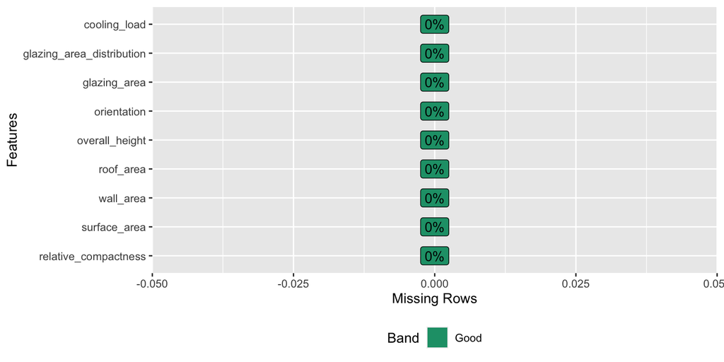

Figure 1: Missing values by variable in the energy efficiency dataset.

## Number of distinct values

| variable | number_distinct_values |
| --- | --- |
| overall_height | 2 |
| roof_area | 4 |
| orientation | 4 |
| glazing_area | 4 |
| glazing_area_distribution | 6 |
| wall_area | 7 |
| relative_compactness | 12 |
| surface_area | 12 |
| cooling_load | 636 |

## Outcome variable distribution

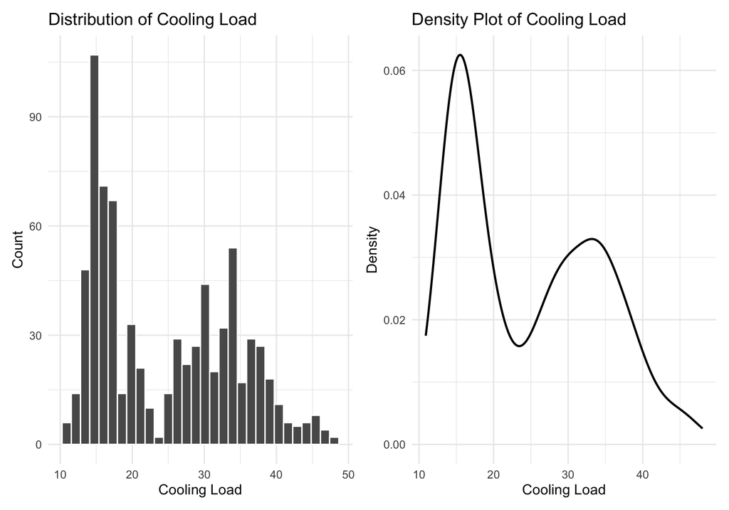

Figure 2: Distribution of the cooling load outcome variable. The left panel shows a histogram and the right panel shows a density plot.

## Distributions of the numeric predictors

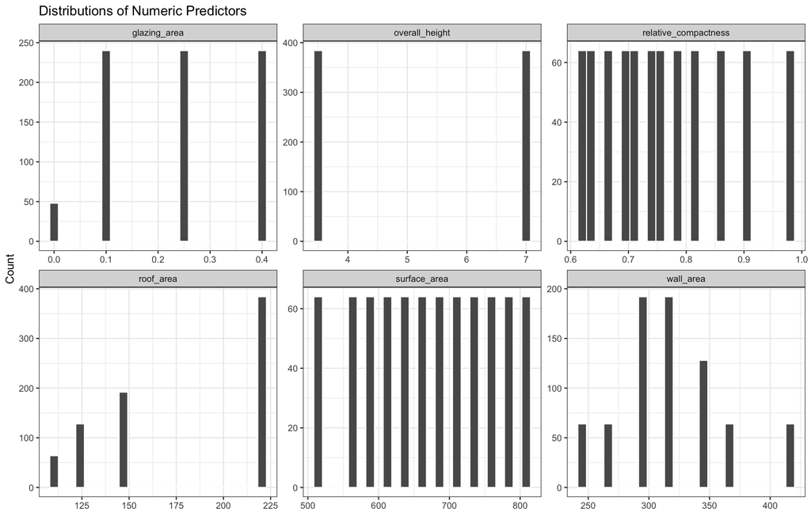

Figure 3: Distributions of the numeric predictor variables.

## Counts for categorical predictors

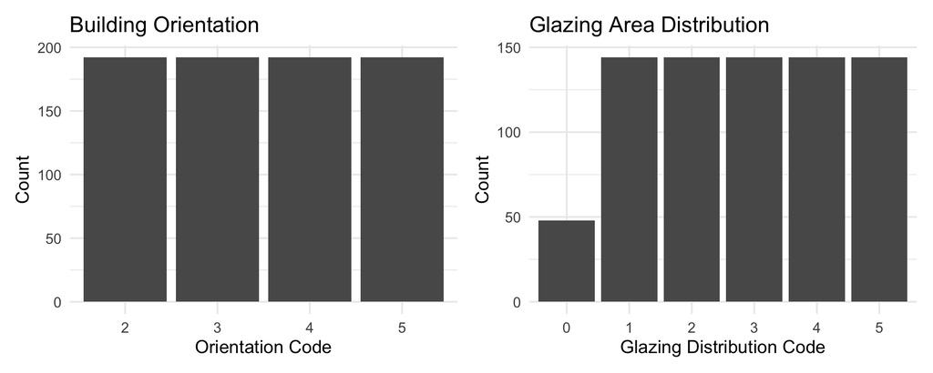

Figure 4: Counts for the categorical predictor variables: building orientation and glazing area distribution.

## Numeric predictors versus cooling load

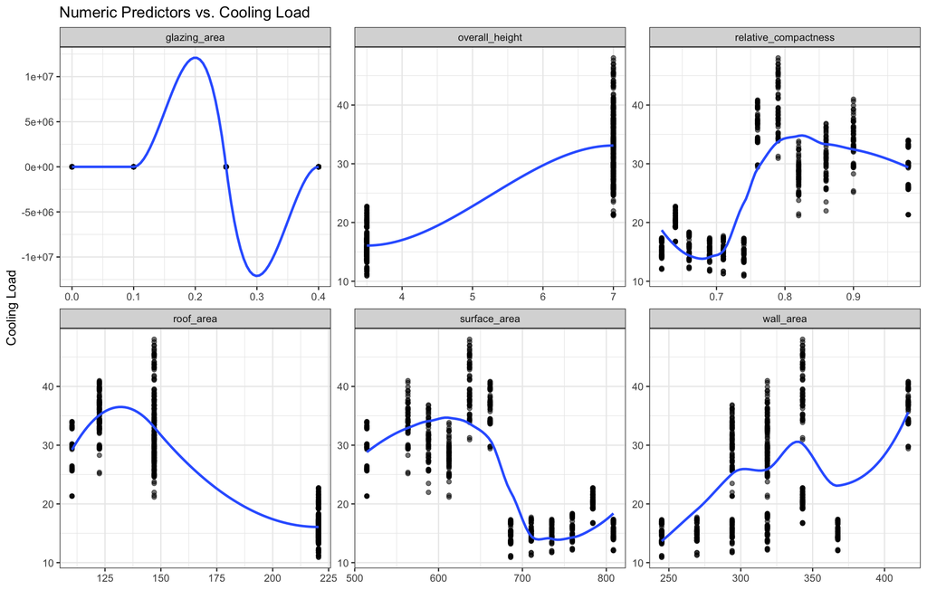

Figure 5: Relationships between each numeric predictor and cooling load. Smooth curves are included to highlight possible nonlinear patterns.

## Categorical predictors versus outcome

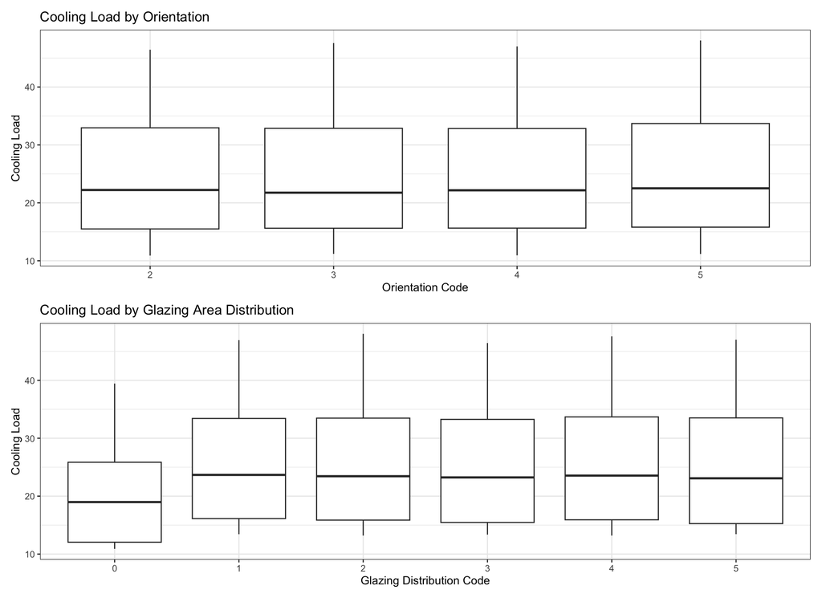

Figure 6: Cooling load by the categorical predictor variables: orientation and glazing area distribution.

## Correlation matrix

| variable | relative_compactness | surface_area | wall_area | roof_area | overall_height | orientation_numeric | glazing_area | glazing_area_distribution_numeric | cooling_load |
| --- | --- | --- | --- | --- | --- | --- | --- | --- | --- |
| relative_compactness | 1.000 | -0.992 | -0.204 | -0.869 | 0.828 | 0.000 | 0.000 | 0.000 | 0.634 |
| surface_area | -0.992 | 1.000 | 0.196 | 0.881 | -0.858 | 0.000 | 0.000 | 0.000 | -0.673 |
| wall_area | -0.204 | 0.196 | 1.000 | -0.292 | 0.281 | 0.000 | 0.000 | 0.000 | 0.427 |
| roof_area | -0.869 | 0.881 | -0.292 | 1.000 | -0.973 | 0.000 | 0.000 | 0.000 | -0.863 |
| overall_height | 0.828 | -0.858 | 0.281 | -0.973 | 1.000 | 0.000 | 0.000 | 0.000 | 0.896 |
| orientation_numeric | 0.000 | 0.000 | 0.000 | 0.000 | 0.000 | 1.000 | 0.000 | 0.000 | 0.014 |
| glazing_area | 0.000 | 0.000 | 0.000 | 0.000 | 0.000 | 0.000 | 1.000 | 0.213 | 0.208 |
| glazing_area_distribution_numeric | 0.000 | 0.000 | 0.000 | 0.000 | 0.000 | 0.000 | 0.213 | 1.000 | 0.051 |
| cooling_load | 0.634 | -0.673 | 0.427 | -0.863 | 0.896 | 0.014 | 0.208 | 0.051 | 1.000 |

## Pair plot for selected variables

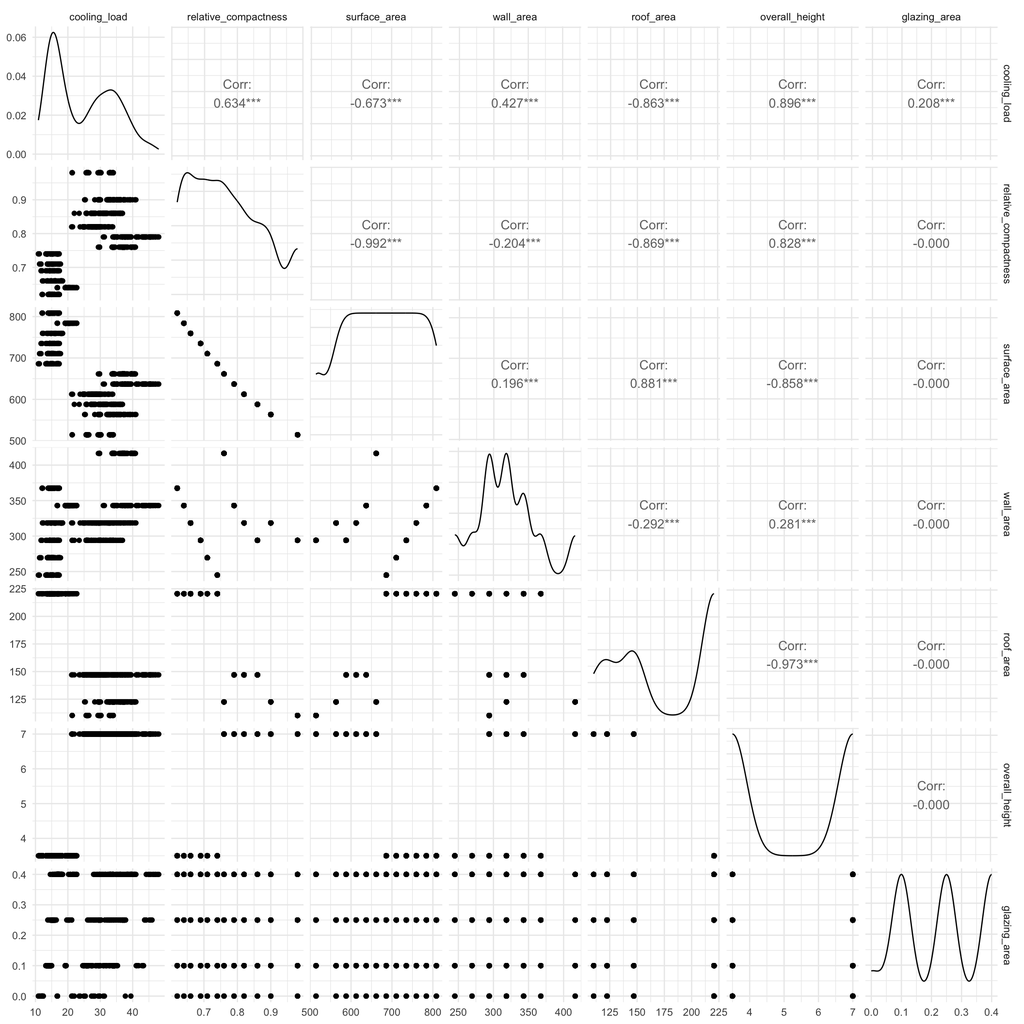

Figure 7: Pair plot showing relationships among cooling load and selected numeric predictor variables.

## Mean outcome by orientation

| orientation | n | mean_cooling_load | sd_cooling_load |
| --- | --- | --- | --- |
| 2 | 192 | 24.60 | 9.61 |
| 3 | 192 | 24.31 | 9.31 |
| 4 | 192 | 24.48 | 9.38 |
| 5 | 192 | 24.95 | 9.81 |

## Mean outcome by glazing area distribution

| glazing_area_distribution | n | mean_cooling_load | sd_cooling_load |
| --- | --- | --- | --- |
| 0 | 48 | 19.71 | 8.13 |
| 1 | 144 | 25.18 | 9.55 |
| 2 | 144 | 25.00 | 9.56 |
| 3 | 144 | 24.66 | 9.49 |
| 4 | 144 | 25.02 | 9.56 |
| 5 | 144 | 24.72 | 9.53 |

## Mean outcome by glazing area and overall height

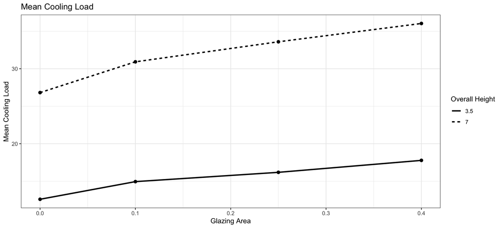

Figure 8: Mean cooling load by glazing area, separated by overall building height.

## Correlations with the outcome

| variable | outcome | correlation | abs_correlation |
| --- | --- | --- | --- |
| overall_height | cooling | 0.896 | 0.896 |
| roof_area | cooling | -0.863 | 0.863 |
| surface_area | cooling | -0.673 | 0.673 |
| relative_compactness | cooling | 0.634 | 0.634 |
| wall_area | cooling | 0.427 | 0.427 |
| glazing_area | cooling | 0.208 | 0.208 |
| glazing_area_distribution_numeric | cooling | 0.051 | 0.051 |
| orientation_numeric | cooling | 0.014 | 0.014 |

# Data Read and Split

Start by splitting your data. Use the following code to ensure consistency between students for the training and testing sets.

```r
cooling <- read_csv("FILL IN DATA LOCATION") |>
  mutate(
    orientation = factor(orientation),
    glazing_area_distribution = factor(glazing_area_distribution)
  )

set.seed(2026)

cool_split <- initial_split(
  cooling,
  prop = 0.70)

cool_train <- training(cool_split)
cool_test  <- testing(cool_split)
```

You should use `cool_train` for model fitting, model selection, and tuning. The test set, `cool_test`, should be used for final model evaluation.

# Questions

1. Before fitting models, describe your overall modeling strategy. Your answer should be specific to this dataset. Use the provided EDA by referencing the Figure labels when possible.
2. Fit and compare the following regression models. To receive full points you need to not only fit each model, but also use tuning where necessary and include relevant outputs (tables/plots/variable lists) where relevant.

**Note**

You must fit all listed model types. However, for tree-based and regularized models, a modest tuning grid is acceptable. Your goal is a correct, thoughtful workflow, not an exhaustive search over every possible tuning parameter.

**Tip**

When naming your models in your code use the abbreviations below.

- (MLR) multiple linear regression
- (BSS) best subset selection
- (RR) ridge regression
- (LASSO) lasso regression
- (EN) elastic net regression
- (PCR) principal components regression
- (PLS) partial least squares regression
- (DEC) decision tree
- (BAGT) bagged trees
- (RF) random forest
- (BOOST) boosted trees

#### For each model you fit, clearly report:

1. the model type
2. the tuning parameters considered and selected, when applicable
3. the estimated predictive performance using RMSE, including the final test-set RMSE
3. Final Model Comparison

Create one organized table containing **all models you fit**.

Your table should include:

- model name
- selected tuning parameters, if applicable
- test-set RMSE

Sort the table from smallest test-set RMSE to largest test-set RMSE. Choose the best model considering the practical usability and model performance.

4. **Final** Model Interpretation and Assessment

Your answer should address the following:

1. Which model did you choose as your final model?
2. Why did you choose this model?
3. What does the model suggest about predicting cooling load?
4. Which predictors are most important?
5. Assess model conditions or limitations.
5. Competition Submission — Bonus Points

At the end of your document, clearly state your final model’s test-set RMSE in the following format:

```r
final_rmse <- YOUR_FINAL_TEST_RMSE_HERE

final_rmse
```

Also include the following sentence:

> My final model for the class competition is: `[model name]`, with a test-set RMSE of `[value]`.

The class winner will be determined by the smallest test-set RMSE. The top 5 models will receive bonus points with 1st place getting 5 points, 2nd place getting 4 points, and so forth.

## Scoring Summary

| Section | Points |
| --- | --- |
| 1. Modeling strategy | 5 |
| 2. Fitting, tuning, and reporting all required models | 33 |
| 3. Final model comparison table and model choice | 5 |
| 4. Final model interpretation and assessment | 5 |
| Analysis organization | 2 |
| **Total** | **50** |
| Competition submission | Required; up to 5 bonus points |

## Notes

You should not simply try one model and stop. A strong submission will compare multiple modeling approaches, tune models when appropriate, and explain the reasoning behind the final model choice.

Your grade will depend on:

- correctness of the modeling workflow
- thoughtful use of validation or resampling
- appropriate preprocessing
- reasonable tuning
- clear model comparison
- meaningful interpretation
- awareness of model limitations

The class competition is based only on test-set RMSE, but your exam grade is based on the quality of your full analysis.